# Project Writeup

```r
library(phyloseq)
library(tidyverse)
library(tibble)
library(dplyr)
library(cowplot)
library(grid)
library(readxl)
library(dplyr)
library(vegan)
library(ggrepel)
library(PCAtools)
library(pca3d)
library(factoextra)
library(vegan)
library(MASS)
library(here)
knitr::opts_chunk$set(echo = TRUE)
```

**Table of contents**

[1] Concept  
[2] Background of Dataset  
[3] Notes on Statistical Methods Used  
[4] Methodology & Results  
[5] Codes Section  
[6] Figures Section  
[X] References

**Concept**<sup>Return</sup>

Principal component analysis (PCA) is commonly used in ecological studies, such as bacterial microbiota & fungal mycobiota analyses, with many papers not providing a clear interpretation of the results. How does PCA reduce data dimensionality and what is the interpretation, also is PCA an appropriate method for “-biota” analyses? I will investigate the mathematics behind PCA and determine how dimensionality is reduced. Furthermore, I will examine if PCA is appropriate for community driven beta-diversity analysis, which infers ecological structural differences between individuals.  
This is important because inferring beta-diversity differences between individuals can give us an insight on core community diversity between a normobiosis patient versus a dysbiosis patient. This meaning, the organisms residing in a healthy individual may vastly differ when compared to an individual suffering from a particular disease. If this statement holds true, then PCA, or other dimensionality reduction techniques, may give us insight on whether differences in community composition is associative to a particular disease (such as immune mediated inflammatory diseases).  
My investigation into PCA has led me to unsupervised dimensionality reduction methods, called ordination. Collectively, these methods attempt to reduce dimensions of a multivariate dataset while retaining ordered grouping relationships between variables. The goal of ordination methods is to provide visualization of grouped relationships in a reduced multidimensional space. I will address three ordination techniques and attempt to determine which works better for community-based beta-diversity analysis.

**Background of Dataset**<sup>Return</sup>

The dataset I have chosen for this study comes from the authors [Zuo et al. (2019)](https://www.nature.com/articles/s41467-018-06103-6/). This is a study conducted on patients suffering from recurrent *Clostridium difficile* infection (CDI), who have underwent fecal microbiota transplant (FMT) during the course of the study by using the fecal organism community from a matched donor control patient. *C.difficile* is a bacterial organism that can infect the human intestine, leading to inflammation and causing diarrhea, fevers, bloody stool, as well as abdominal pains.  
Current treatment for CDI infection involves antibiotic intervention, but *C.difficile* is becoming adaptively resistant as well as inherently resistant due to sporulation inactivity. As such, FMT treatment is becoming an increasingly effective method in treating recurrent CDI. The idea behind FMT is, a matched healthy donors stool sample will contain a normobiosis community of bacterial organisms. Once the donor stool is transplanted into a CDI patient, this normobiosis community of organisms is suspected to outcompete *C.difficile* colonization of the gut. This should result in decreased CDI and associated symptoms because the organisms from the donor community becomes inhabitants the CDI patients gut.  
The authors of this particular study is interested in the fungal community, the mycobiome, of the donors fecal sample as compared to their FMT matched CDI patient. Of note, the authors sequenced the fungal internal transcribed spacer (ITS2) region of 16 donor patient stools and their matched CDI recipients. They investigated the fungal communities through metataxonomic analysis, while collecting longitudinal samples from CDI patients during and post-FMT (67 samples in total). Out of the 16 FMTs, 9 patients exhibited no CDI symptoms (CDI1 to CDI9) and their fecal communities became similar to that of the donors; 7 patients were partially/not cured, and after a certain period of time, they reverted to recurrent CDI.  
This study implies that the gut fungal community of an individual may play a role in preventing recurrent CDI. As such, I will apply ordination methodologies to see if the donors fungal community is similar to the CDI recipient community, especially in the case of the 9 cured patients.

**Notes on Statistical Methods Used**<sup>Return</sup>

As previously stated, ordination based techniques are useful for ordering grouped relationships and in particular for ecological community analyses. Ordination works by providing a visualization of multivariate data due to a reduction of dimensions while maintaining the most relevant information contributing to the data (McCarthy, n.d.; OM, n.d.). This allows us to visualize data that would otherwise be humanly impossible to view in higher dimensions. In indirect ordination analysis, a counts table containing “species” abundance for a certain ecological community is used for analysis. Indirect ordination is able to infer lurking relationships by using the redundancy within a dataset. This is because multiple “species” within the count table will share a similar distribution of abundances which forms redundancy, an advantage used by ordination to order related groups.  
An Eigenanalysis based technique is the principal component analysis (PCA), which uses linear matrix algebra to calculate Eigenvalues and their associated Eigenvectors (Lever, 2017; McCarthy, n.d.; Shlens, 2014; Smith, 2002; Wold, 1987). Eigen calculations are performed by Eigendecomposition or singular value decomposition (SVD), both of which yield similar results (OM, n.d.; SV, n.d.). In Eigendecompostion, the data is first scaled by standardization (dividing the observations by the column standard deviation) and/or centered (subtracting the observations by the column mean). Standardization is performed if the compared variables (the columns) are in different units of measurements, which does not have to be performed on ecological counts abundance tables because the measurements are unitless. While centering is performed to bring the centroid of the group of points to the (0,0) coordinate, without altering the ordering. Centering in particular is not essential to the analysis, as it does not effect the overall ordering.  
Eigenanalysis requires a squared/symmetrical matrix to perform linear operations, and this is established through correlation or covariance calculation of the initial matrix. In the case of correlation calculations, this is again used if the initial variables contain different units. Again, ecological counts tables are unitless, so a covariance calculation is appropriate in generating a symmetrical covariance matrix for linear application. Both correlation and covariance calculations depend on comparing between two variables (“species”) of a particular sample, which helps distinguish relationships within a community.  
Without going into too much mathematics, the next step is to calculate Eigenvalues by finding the determinant of the squared covariance matrix. The number of Eigenvalues should be equivalent to the lowest number of variables in the dataset (either number of samples, or number of “species”), and eigenvalues indicate variance which is used to project a lower dimensionality (AKA principal components (PCs)). Using the calculated Eigenvalues, the corresponding Eigenvectors are next calculated and normalized based upon the associated Eigenvalue. Eigenvectors correspond the the weights/loadings used to plot the new coordinates of datapoints in a reduced space.  
Since multiple PCs are generated, Eigenvalues (PCs) are visualized as a barchart (screeplot) based upon the proportion of the total variation accounted by each PC. The most informative PCs will account for the most variance and should be used to visualize the transformed data in reduced space. This is dimensionality reduction while preventing loss of too much information because PCs accounting for low variation in data is assumed to be not very informative in finding ordered relationships. It should be noted that each PC is orthogonal to eachother, so this indicates an initial assumption of no relation between axes.  
There are certain limitations in performing PCA, one of which is because PCA calculation using a covariance/correlation matrix is a Euclidean measure of distance. This means that it assumes the data is linearly connected, which is why PCA is a linear model of ordination. This is especially bad in the case of ecological community analysis, where data is very sparse with a high number of 0 counts. The result of this limitation is seen in my analysis, where a “horseshoe”-like shape is visualized and is not very informative (Figure 2). This “horseshoe”-like shape is said to appear when there is a high amount of beta-diversity between samples (OM, n.d.).  
Other ordination techniques involve using a distance matrix instead of covariance/correlation matrix for finding ordered relationships. Metric multidimensional scaling (MDS), also known as principal coordinate analysis (PCoA), is one of such techniques (McCarthy, n.d; MS, n.d.; OM, n.d). MDS is exactly the same as PCA, in the sense that it performs Eigenanalysis. In fact, if you used a Euclidean measure for a distance matrix and input this matrix to calculate MDS, the output would be the exact same as PCA (Figures 2 & 7). MDS is an improvement compared to PCA because it allows you to provide distance measures other than Euclidean, this escaping the linear limitation of Euclidean distance; however, MDS attempts to maximize linear distances between points. So the major limitation to MDS is finding a distance measure which best fits the data.  
Similarly, nonmetric multidimensional scaling (NMDS) also intakes a distance matrix for calculation (McCarthy, n.d; MS, n.d.; OM, n.d). This technique differs from PCA and MDS, in the sense that the order of the axes is arbitrary so that no one axis is more important than the other. Although I do not have a complete grasp of this method, I understand that the main goal is to separate similar points from dissimilar points. Also, NMDS does not by maximize linear distances but maximizes ranking orders. This process is said to be iterative, in which you first choose the number of dimensions to transform data observations. The iteration process causes convergence at some point, or stops when a low stress value is calculated (a stress value is a goodness-of-fit measure). Due to time limitation on this project, I plan on looking into the NMDS algorithm further in the future.

**Methodology & Results**<sup>Return</sup>

**Obtaining Data Using Galaxy**  
From the article by [Zuo et al. (2019)](https://www.nature.com/articles/s41467-018-06103-6/), the associated fungal ITS2 MiSeq dataset is found on [NCBI BioProject (PRJNA419104)](https://www.ncbi.nlm.nih.gov/sra?linkname=bioproject_sra_all&from_uid=419104). A file containing all the sequence accessions is exported and uploaded onto an online collection of bioinformatic tools, [Galaxy tools](https://usegalaxy.org/). On Galaxy, the sequencing collection associated with their linking accessions is downloaded using the “Faster Download and Extract Reads in FASTQ format from NCBI SRA” tool. The “List of SRA accession, one per line” parameter for this tool allows for the extraction of paired-end sequences from BioProject. The resulting file must be unzipped and the file type must be changed for downstream analysis. Using Bash, I renamed the “.fastqsanger” extension to the format, "_L001_R#_001.fastq", for downstream processing.

**FASTQ Header Processing**  
FASTQ files extracted by Galaxy contains improper headers for downstream operational taxonomic units (OTUs) analysis (i.e. @1/1). I created two Bash scripts, HeaderRenameR1.sh and HeaderRenameR2.sh, to rename forward reads (R1) and reverse reads (R2) into the format “#Sample Accession_L001/#”. Briefly, each script searches for forward (R1) or reverse (R2) FASTQ files, and pastes the associated accession ID as the header. The number in front of the accession header prevents overlapping names, while the number at the end of the header distinguishes forward reads (1) from reverse reads (2) for paired-end files. To run the scripts, place them in the same folder as the FASTQ files and execute `./headerrenameR#.sh outputfolder/`

**LotuS Pipeline OTU Analysis**  
[Less operational taxonomic units scripts (LotuS)](https://microbiomejournal.biomedcentral.com/articles/10.1186/2049-2618-2-30) is a metataxonomic tool which allows for fungal ITS2 amplicon based taxonomic clustering and classification (Hildebrand et al., 2014). This tool needs to be installed on a Bash based system, and there is information online [aiding installation](http://psbweb05.psb.ugent.be/lotus/documentation.html). Note that [USEARCH](http://www.drive5.com/usearch/download.html) must be downloaded separately for this tool to work. To use this tool, a mapping file is first generated using the `./autoMap.pl` command which pairs the forward and reverse FASTQ files for clustering. The following `./lotus.pl` command is used to cluster the sequences into OTUs based upon a percent similarity. I set the parameters for identification of fungal organisms using the fungal ITS2 region mapped to the UNITE reference database, and sequence processing is done using the MiSeq settings with a minimum requirement of a 100 bp overlap.

**Metadata Analysis**  
Metadata associated with CDI infected patients, their matched controls, number of replicates, and relapse status is provided by Zuo et al. (2019), [in supplementary data 3 and 4 of their article](https://www.nature.com/articles/s41467-018-06103-6/#Sec29). In brief, 16 CDI patients underwent FMT (FMT1 to FMT16) with their numerically matched donors (Control1 to Control16). After transplant, CDI patients were sampled for a longitudinal period (authors supplementary information Figure 2). From [NCBI BioProject (PRJNA419104)](https://www.ncbi.nlm.nih.gov/sra?linkname=bioproject_sra_all&from_uid=419104), I exported a excel format summary file of all FASTQ sequences and used Microsoft excel for further operations. I added the columns, “Patient” & “SORT BY” beside the existing “Study Accession” column. The “SORT BY” column contains data associated with replicate samples, found in the authors supplementary data 4, and the column “Patient” contains abbreviated patient identifiers (P for patient and C for control). Using excel, I performed a expanded sort on the “Experiment Title” column, based upon the “SORT BY” column ordering. This is to get the column “Study Accession” into order by grouping replicates because the counts table derived by processing LotuS output in Rstudio, contains accession identifiers as sample identifiers.

**PCA Analysis**  
Before starting ordination analysis, I generated a dataframe to group samples into “CDI” and “Controls” for visual separation in later plots (groupingstable). Briefly, I took the sample identifiers from the transposed counts table (OTUanalysis) and grouped them into two of the mentioned levels. To perform PCA analysis, I used the library “PCAtools” from BioConductor because it contained multiple functions for visualizing PCA plots. The initial function to perform SVD calculation for Eigenvalues and their associated Eigenvectors is `pca()`. I viewed the code for this function provided in PCAtools and realized it uses `prcomp()` for Eigen calculations, but lacks a standard deviation output. The standard deviation output is important because I can cross-check if the Eigenvalues outputted by PCAtools match other calculation functions, such as `Eigenvalue()` (Note standard deviation<sup>2</sup> AKA the variance is the Eigenvalues). To supplement the `pca()` function, I added the “sdev” output from `prcomp()` calculation (sdev = pcaobj$sdev). I also realized that `pca()` transposes the input counts table, which would mean the calculations are based upon sample to sample covariances not community (in the case of Eigendecomposition calculation, which results similar to SVD). I fixed the problem by removing “t(mat)” from their script, which also required me to edit their metadata grouping length restriction (“!all(colnames(mat) == rownames(metadata)” changed to “all(colnames(mat) == rownames(metadata))”). I formulated these changes into the edited `pca1()` function based upon the original `pca()` function from PCAtools, which can still be inputted into their other tools.  
Using the edited `pca1()` function, I set the arguments inputting the OTUanalysis dataframe, and groupingstable for grouping information, as well as using centering scaling by subtracting column means. I then obtained transformed coordinates for multiple principal components (PCs), which is based upon the number of columns (OTU) in the OTUanalysis dataframe. In the first step of PCA, I visualized the PCs using the `screeplot()` function, which indicated PC1 to PC3 accounting for most of the sample variance (Figure 1). I then plotted a `biplot()` to see how PC2 against PC1 would look like in 2-dimension, it has a v-like/parabolic shape which is a limitation of PCA (Figure 2).  
To confirm this, I tested the `pairsplot()` function to see how multiple PCs would look like and the similar v-like shape is seen (Figure 3). The output of `pairsplot()` gave numerical variances accounted by each PC, and as screeplot indicated, PC1 to PC3 does account for most of the variance (84%). This indicates that a 3-dimensional visualization of PC1 to PC3 is necessary to view most of the variance between samples. To do this, I used the package “pca3d” because it allows for 3D PCA plots. The resulting 3D PCA plot of PC1 to PC3 shows the familiar v-like shape in 3 dimensional space (Not shown).  
I double checked these results using step-by-step Eigendecomposition calculations, as well as an alternative PCA analysis tool “factoextra” mentioned in the textbook and the results correspond well (Figures 4 & 5). The codes used for this section is found below in the “PCA Analysis” codes section.

**MDS and NMDS Analysis**  
MDS and NMDS analysis both intake a distance matrix to perform matrix transformations. Starting with MDS, I used the “vegan” package and the function `vegdist()` to perform a distance measure using the Jaccard distance method. Then I used “stats” package which allows for MDS based Eigen calculations on a distance matrix. By using the function `cmdscale()`, where I selected the argument “k=2”, the output is for components MDS1 and MDS2 which are equivalent to PCs in PCA; however, the similarity of CDI cured samples, and their matching controls, are grouped more distinctively when compared to PCA (Figures 6 & 2)  
I also analyzed MDS using the Euclidean distance measure, and the output is identical to the above PCA analysis (Figure 7). This is expected because PCA is known as a Euclidean method of ordination analysis. Alternatively, Bray–Curtis dissimilarity could have been used to calculate the distance matrix, which would result similar to the Jaccard distance calculation (Figures 6 & 8). I chose the Jaccard measure arbitrarily, which is a limitation of this study because finding the correct distance measure for the data requires further investigation. The codes used for MDS analysis is found at the “MDS Analysis” section in codes.  
For NMDS analysis, I again used the “vegan” package with the function `metaMDS()` which iteratively tries to calculate the lowest stress value (a goodness of fit measure). The number of iterations, as well as stress value, will differ per run because `metaMDS()` starts calculations at different points. For this analysis I kept the distance measure as Jaccard to compare with the MDS method. I also kept the same argument, “k=2”, to calculate for components NMDS1 and NMDS2. The output graph more distinctly orders CDI cured patients with their matched controls, as compared to MDS (Figure 9).  
To check between distance measures, I applied the Bray–Curtis distance measure in NMDS and it resulted in similar plot to the Jaccard measure NMDS plot (Figure 10). Codes used in NMDS analysis is found below.

**Codes**<sup>Return</sup>

**File Extension Rename**

```bash
shopt -s globstar
rename .fastqsanger _L001_R1_001.fastq collection\ 4\ \(forward\)/** # For forward reads
rename .fastqsanger _L001_R2_001.fastq collection\ 4\ \(reverse\)/* # For reverse reads
```

**LotuS Commands**

```bash
./autoMap.pl FASTQfolder/ ProjectMapping.txt 2 #where 2 represents paired-end reads
./lotus.pl -i FASTQfolder/ -m MappingFile.txt -o OutputFile -s sdm_miSeq.txt -p miSeq -highmem 1 -refDB ./DB/ITSxUSEARCH.fasta -tax4refDB ./DB/ITSxUSEARCH.tax -itsextraction 1 -readOverlap 100 -keepUnclassified 1 -tax_group fungi
```

**HeaderRenameR1.sh**

```bash
#!/bin/bash

fastqdir=$1

#this renames headers of R1 reads
for w in `ls $fastqdir/*R1_001.fastq | xargs -n 1 basename | sed 's/_R1_001.fastq//'` #prints out only the SRR######
do
    cat "$fastqdir/$w"_R1_001.fastq | awk -v names="$w/1" '{print (NR%4 == 1) ? "@"++i names : $0}' > "$fastqdir/$w"_R1_001.fastq.renamed
done
```

**HeaderRenameR2.sh**

```bash
#!/bin/bash

fastqdir=$1

#this renames headers of R2 reads
for w in `ls $fastqdir/*R2_001.fastq | xargs -n 1 basename | sed 's/_R2_001.fastq//'` #prints out only the SRR######
do
    cat "$fastqdir/$w"_R2_001.fastq | awk -v names="$w/2" '{print (NR%4 == 1) ? "@"++i names : $0}' > "$fastqdir/$w"_R2_001.fastq.renamed
done
```

**Data Wrangling**

```r
#NOTE - I realized I could have just downloaded FASTQ files corresponding to the 16 Cases+replicates & controls to save myself from all this trouble but it was already too late when I started & re-read the article

#Set directory for loading in files
pathOTU <- here("FinalProject", "FinalWorkflow","FinalData", "LotuSOutput", "OTU.txt")
pathSamples <- here("FinalProject", "FinalWorkflow","FinalData", "LotuSOutput", "ProjectMapping.txt")

#Vector containing acession IDs for controls
controls <- c("SRR6308536", "SRR6308532", "SRR6308512", "SRR6308508", "SRR6308518", "SRR6308526", "SRR6308541", "SRR6308540", "SRR6308546", "SRR6308554", "SRR6308556", "SRR6308500", "SRR6308452", "SRR6308449", "SRR6308464", "SRR6308465", "SRR6308502", "SRR6308504", "SRR6308506", "SRR6308492", "SRR6308491", "SRR6308490", "SRR6308489")
  length(controls) #see how many controls

#Loading files & Data Wrangling
OTU <- read.table(pathOTU, header=TRUE, row.names = 1, sep="\t") #this loads OTU.txt - the count table
  #Get accession ID onto column headers
    samples <- read.table(pathSamples, header=FALSE, row.names =1, sep="\t") #this loads in the mapping file for paired-end reads
    samples$V2 <- gsub("_L.*", "",samples$V2) #Trim unwated characters for sample accession labels (note regex wild card(.) & 0 or more (*))
    names(samples) <- 'sampleN' #give column labels from OTU table to sample file to match identifiers
    names(OTU) <- samples$sampleN #set OTU table column names according to samples dataframe created above

#Subset and split
  #Subset by Controls (Donors)
    OTUcc <- OTU[,tidyselect::vars_select(names(OTU), controls)] #separate out controls based upon above control accession vector
      length(names(OTUcc)) #double check if correct length of controls (23)
      names(OTUcc) <- paste("Control", 1:23, sep="_") #rename control dataframe columns to Control_# for easier plotting visualization
      OTUc <- OTUcc[,1:16] #subset for 16 FMT donors (controls)

  #Subset by Cases (Recipients)
    OTUs <- OTU[,tidyselect::vars_select(names(OTU), -controls)] #separate out case samples

#Load in metadata
  sra_result <- read_excel(here("FinalProject", "FinalWorkflow","FinalData", "sra_result.xlsx")) #load sorted metadata
  sra_result1 <- sra_result[c(2,4)] #subset the important columns (SRR matching replicates)
   cont <- paste("Control", 1:23, sep="") #make a vector of control values for next step to remove
  sra_result1.1 <- subset(sra_result1, !`Experiment Title` %in% cont) #Remove controls
  sra_result1.2 <- sra_result1.1[1:51,] #subset for the 16 FMT patients & associated replicates


#Pull out the 16 case patients w/ FMT from Case dataframe
  OTUn <- OTUs[ , sra_result1.2$`SRR Accession`]
    names(OTUn) <- sra_result1.2$`Experiment Title` #rename samples - NOTE GIVING ARBITARY NON-SAMPLE MATCHING NAMES (fix when needed in MS project)

# Generate a re-combined case+control dataframe
  OTUa <- cbind(OTUn, OTUc) #combine case samples & controls samples again to get controls at the end of the df for easier visualization comparison case/control

# Transposition
  OTUanalysis <- t(OTUa) #Transpose counts matrix for PCAtools pca() to work properly
#This means compare OTUx vs OTUx (columns) for rows (case1 OTU1 vs OTU2, case2 OTU1 vs OTU2)
# via OTUanalysis count table
# COMPARING COMMUNITY STRUCTURE WITHIN THE INDIVIDUAL PLOTTING AGAINST OTHER INDIVIDUALS COMMUNITIES
```

**Grouping File**

```r
#Make groupings for case & controls to distinguish (AKA metadata for PCAtools)
groupings <- gsub("_[0-9]*$", "", rownames(OTUanalysis)) #this removes _# associated with sample names
groupings <- gsub("F.*", "CDI", groupings) #change all the F.... to CDI for common grouping
groupings <- factor(groupings, levels = c("CDI", "Control")) #make explicit levels of groups
groupingstable <- data.frame(groupings=groupings) #put this into a table
rownames(groupingstable) <- rownames(OTUanalysis)  #match corresponding sample IDs to groupings
```

**PCA Analysis**

```r
#HAVE TO EDIT THE pca() function FROM PCA TOOLS
  #added sdev
  #removed prcomp(t(mat))
  #changed !all(colnames(mat) == rownames(metadata) to all(colnames(mat) == rownarmes(metadata)
pca1 <- function (mat, metadata = NULL, center = TRUE, scale = FALSE,
                  removeVar = NULL)
{
  mat <- as.data.frame(mat)
  if (!is.null(metadata)) {
    if (all(colnames(mat) == rownames(metadata))) {
      stop("Colnames of 'mat' object must equal and be in the same",
           " order as the rownames of metadata")
    }
  }
  if (!is.null(removeVar)) {
    message("-- removing the lower ", removeVar * 100, "% of variables based on variance")
    vars <- apply(mat, 1, function(x) var(x))
    varorder <- order(vars, decreasing = FALSE)
    exclude <- varorder[seq_len(nrow(mat) * removeVar)]
    mat <- mat[-exclude, ]
  }
  pcaobj <- prcomp(mat, center = center, scale. = scale,
                   retx = TRUE, tol = NULL, rank. = NULL)
  proportionvar <- ((pcaobj$sdev^2)/(sum(pcaobj$sdev^2))) * #this is the proportion standard deviation outputted as variance...
    100
  pcaobj <- list(rotated = data.frame(pcaobj$x), loadings = data.frame(pcaobj$rotation),
                 variance = proportionvar, sdev = pcaobj$sdev, metadata = metadata, xvars = rownames(mat),
                 yvars = colnames(mat), components = colnames(pcaobj$x))
  names(pcaobj$variance) <- pcaobj$components
  class(pcaobj) <- "pca"
  return(pcaobj)
}

#PCA analysis
  #PCAtools
    PCA <- pca1(OTUanalysis, metadata=groupingstable, scale=F, center=T) #Generate Eigen calculations & transformed coordinates - note loadings = rotated, rotated=x from prcomp()
      summary(PCA)

    screeplot(PCA, axisLabSize=10, vline=3.5) #Generate screeplot

    #biplot w/ labels
      biplot(PCA, x='PC1', y='PC2',
             lab=T,
             labSize=3,
             colby = 'groupings', colkey = c('CDI'='tomato', 'Control'='turquoise3'),
             hline = 0, vline = 0,
             legendPosition = 'right',
             pointSize = 3.0)
    #biplot w/o labels
      #biplot(PCA, x='PC1', y='PC2',
      #       lab = F,
      #       colby = 'groupings', colkey = c('Case'='lightblue', 'Control'='pink'),
      #       hline = 0, vline = 0,
      #       legendPosition = 'right') + xlim (-1e5,1e5) #note +xlim or +ylim will adjust graph for visualization

    #Pairsplot
      pairsplot(PCA, colby='groupings') #check multiple PCs

# By pairs plot -> can see PC1 accounts for 29.47% of variation, PC2 27.7% of variation & PC3 = 19.1% of variation (in total 76.27)
  # A 3d plot may be better to represent all the variation (PC1 to PC3 = 84%)
  p3d <- prcomp(OTUanalysis, scale=F, center=T)
  pca3d(p3d, component=1:3, group=groupingstable$groupings,radius = 3, legend = "right", show.ellipses=T, show.scale=T)


# NOTE THIS SECTION CONTAINS HIGH COMPUTING REQUIREMENTS
  #Eigenvalue check (EigenDecomp step-by-step)
  pp1 <- scale(OTUanalysis, center=T, scale=F) #centering
  pp1x <- cov(pp1) #covariance matrix
  pp1xe <- eigen(pp1x)$values #subset for Eigenvalues vs p$stdev^2
    paste("This is Eigenvalues from pca1():", PCA$sdev[1:20]^2, "\n",
          "This is Eigenvalues from eigen():", pp1xe[1:20]) #only the 1st 20 Eigen values
  #want to check for new coordinates
  pp1xevec <- eigen(pp1x)$vectors #subset for Eigenvectors
  pp1final <- as.matrix(pp1) %*% pp1xevec[,1] #these should be the new points -cut down to PC1 check only b/c laptop freezes
  #check
    #identical(round(as.matrix(pp1final),0), round(prcomp(OTUanalysis, scale=F,center=T)$x[,1],0)) this doesn't work because of decimals
    cbind(round(as.matrix(pp1final),0),round(PCA$rotated[,1],0)) #use this instead

#Check with alternative PCA package (factoextra)
  #fviz_screeplot(p) #note does not intake class "pca" generated from PCAtools so have to generate via below codes
  ppx <- prcomp(OTUanalysis, center=T, scale=F)
  fviz_eig(ppx) # screeplot looks about the same
  fviz_pca_ind(ppx,
               label=F, #remove all labels so non-messy graph
               col.ind = groupingstable$groupings, # color by groups
               palette = c("#00AFBB",  "#FC4E07"),
               addEllipses = T, # Concentration ellipses
               ellipse.type = "confidence",
               legend.title = "Groups",
               repel = TRUE) + xlim (-1e5,1e5)
```

**PCoA/PCO/MDS Analysis**

```r
MDSdist <- vegdist(OTUanalysis, method="jaccard") #generate distance matrix based on jaccard dissimilarity
MDS <- cmdscale(MDSdist, k=2, eig=T, x.ret=T) #cmdscale is for classical MDS - needs distance matrix
MDS.values <- MDS$points #subset for MDS coordinates
MDS.data <- data.frame(sample=rownames(MDS.values), X=MDS.values[,1], Y=MDS.values[,2]) #Add sample ID column to coordinates

MDSplot <- ggplot(data=MDS.data, aes(x=X ,y=Y, color=groupingstable$groupings)) + #Plot MDS coordinates
  geom_point() +
  theme_bw() +
  xlab("MDS1") +
  ylab("MDS2") +
  ggtitle("MDS plot using Jaccard distance") +
  labs(color='Groups') +
  scale_color_manual(values=c('tomato', 'turquoise3'))

MDSplot + geom_label_repel(aes(label = sample), #Repel sample labels for more clear visualization
                           box.padding   = 0.35,
                           point.padding = 0.5,
                           segment.color = 'grey50') +theme_classic()

#Testing if MDS Euclidean distance = PCA output
MDSdistE <- vegdist(OTUanalysis, method="euclidean") #generate distance matrix based on Euclidean dissimilarity
MDSE <- cmdscale(MDSdistE, k=2, eig=T, x.ret=T) #cmdscale is for classical MDS - needs distance matrix
MDSE.values <- MDSE$points #subset for MDS coordinates
MDSE.data <- data.frame(sample=rownames(MDSE.values), X=MDSE.values[,1], Y=MDSE.values[,2]) #Add sample ID column to coordinates

MDSEplot <- ggplot(data=MDSE.data, aes(x=X ,y=Y, color=groupingstable$groupings)) + #Plot MDS coordinates
  geom_point() +
  theme_bw() +
  xlab("MDS1") +
  ylab("MDS2") +
  ggtitle("MDS plot using Euclidean distance") +
  labs(color='Groups') +
  scale_color_manual(values=c('tomato', 'turquoise3'))

MDSEplot + geom_label_repel(aes(label = sample), #Repel sample labels for more clear visualization
                           box.padding   = 0.35,
                           point.padding = 0.5,
                           segment.color = 'grey50') +theme_classic()

#Testing MDS Bray distance
MDSdistB <- vegdist(OTUanalysis, method="bray") #generate distance matrix based on Bray dissimilarity
MDSB <- cmdscale(MDSdistB, k=2, eig=T, x.ret=T) #cmdscale is for classical MDS - needs distance matrix
MDSB.values <- MDSB$points #subset for MDS coordinates
MDSB.data <- data.frame(sample=rownames(MDSB.values), X=MDSB.values[,1], Y=MDSB.values[,2]) #Add sample ID column to coordinates

MDSBplot <- ggplot(data=MDSB.data, aes(x=X ,y=Y, color=groupingstable$groupings)) + #Plot MDS coordinates
  geom_point() +
  theme_bw() +
  xlab("MDS1") +
  ylab("MDS2") +
  ggtitle("MDS plot using Bray distance") +
  labs(color='Groups') +
  scale_color_manual(values=c('tomato', 'turquoise3'))

MDSBplot + geom_label_repel(aes(label = sample), #Repel sample labels for more clear visualization
                           box.padding   = 0.35,
                           point.padding = 0.5,
                           segment.color = 'grey50') +theme_classic()
```

**NMDS Analysis**

```r
NMDS <- vegan::metaMDS(OTUanalysis, distance="jaccard", k=2, trymax=1000) #generate NMDS coordinates based on jaccard dissimilarity matrix
NMDS.scores <- as.data.frame(scores(NMDS))  #Using the scores function from vegan to extract the site scores (coordinates) and convert to a data.frame
NMDS.scores$site <- rownames(NMDS.scores)  # create a column of site names (samples), from the rownames of NMDS.scores
NMDS.scores$grp <- groupingstable$groupings # add the metadata groupings as a new column

NMDSplot <- ggplot(data=NMDS.scores,aes(x=NMDS1,y=NMDS2,shape=grp,colour=grp),size=3) + #plot NMDS coordinates
  geom_point() + ylim(-1,1) + xlim(-1.2,1.2) +
  ggtitle("NMDS plot using Jaccard distance") +
  scale_color_manual(values=c('tomato', 'turquoise3'))

NMDSplot + geom_label_repel(aes(label = site), #Repel sample labels for more clear visualization
                            box.padding   = 0.35,
                            point.padding = 0.5,
                            segment.color = 'grey50') +theme_classic()

#Testing NMDS Bray distance
NMDSB <- vegan::metaMDS(OTUanalysis, distance="bray", k=2, trymax=1000) #generate NMDS coordinates based on jaccard dissimilarity matrix
NMDSB.scores <- as.data.frame(scores(NMDSB))  #Using the scores function from vegan to extract the site scores (coordinates) and convert to a data.frame
NMDSB.scores$site <- rownames(NMDSB.scores)  # create a column of site names (samples), from the rownames of NMDS.scores
NMDSB.scores$grp <- groupingstable$groupings # add the metadata groupings as a new column

NMDSBplot <- ggplot(data=NMDSB.scores,aes(x=NMDS1,y=NMDS2,shape=grp,colour=grp),size=3) + #plot NMDS coordinates
  geom_point() + ylim(-1,1) + xlim(-1.2,1.2) +
  ggtitle("NMDS plot using Bray distance") +
  scale_color_manual(values=c('tomato', 'turquoise3'))

NMDSBplot + geom_label_repel(aes(label = site), #Repel sample labels for more clear visualization
                            box.padding   = 0.35,
                            point.padding = 0.5,
                            segment.color = 'grey50') +theme_classic()
```

**Figures**<sup>Return</sup>

```
## Square root transformation
## Wisconsin double standardization
## *** Solution reached
```

```
## Square root transformation
## Wisconsin double standardization
## *** Solution reached
```

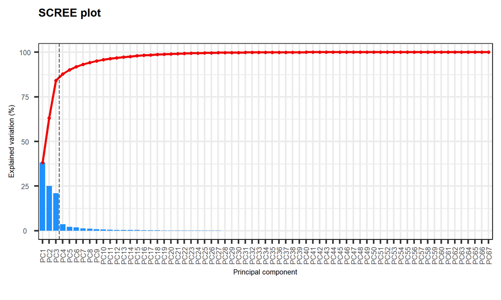

> **Figure 1.** Screeplot from PCAtools.

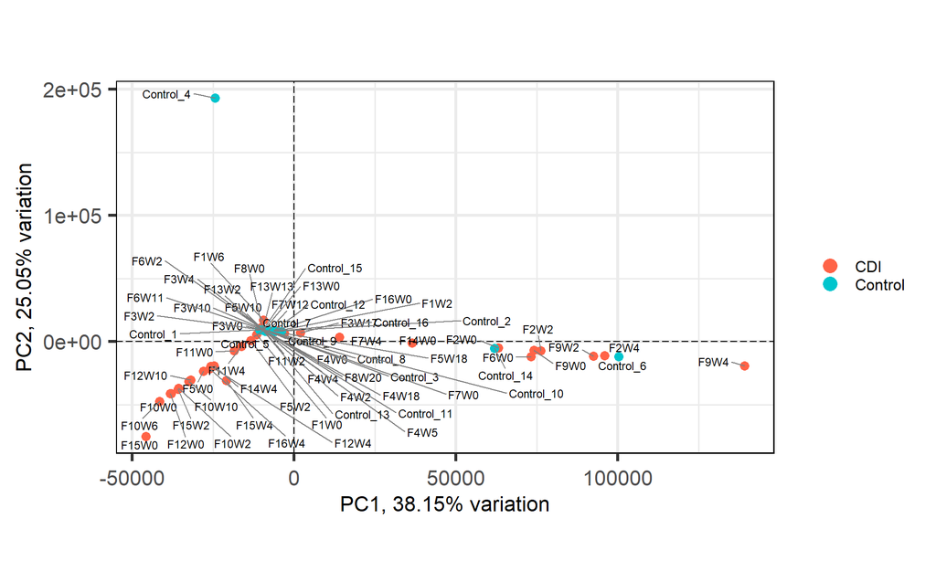

> **Figure 2.** PCA biplot of from PCAtools.

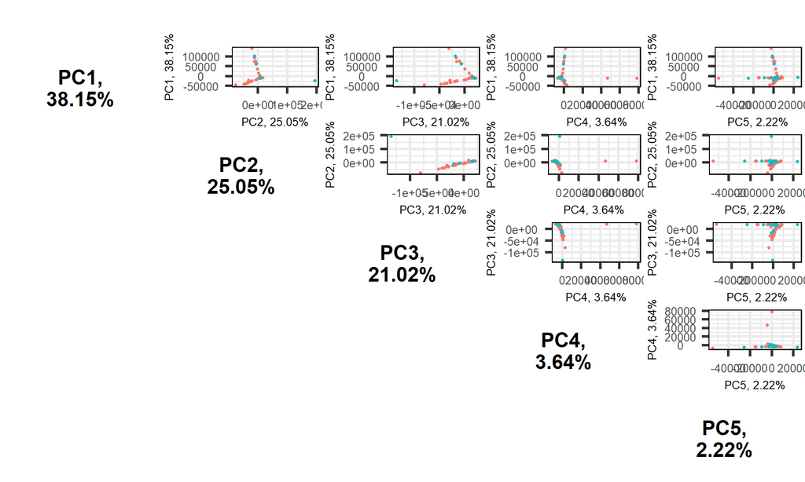

> **Figure 3.** Pairsplot from PCAtools.

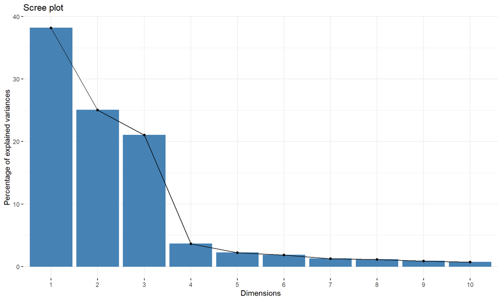

> **Figure 4.** Screeplot from factoextra.

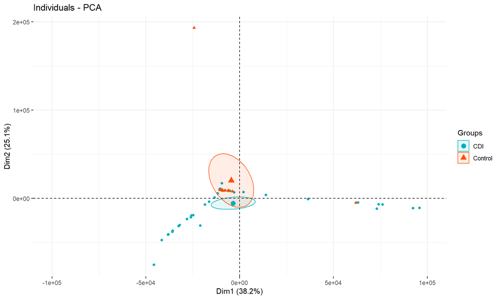

> **Figure 5.** PCA biplot from factoextra.

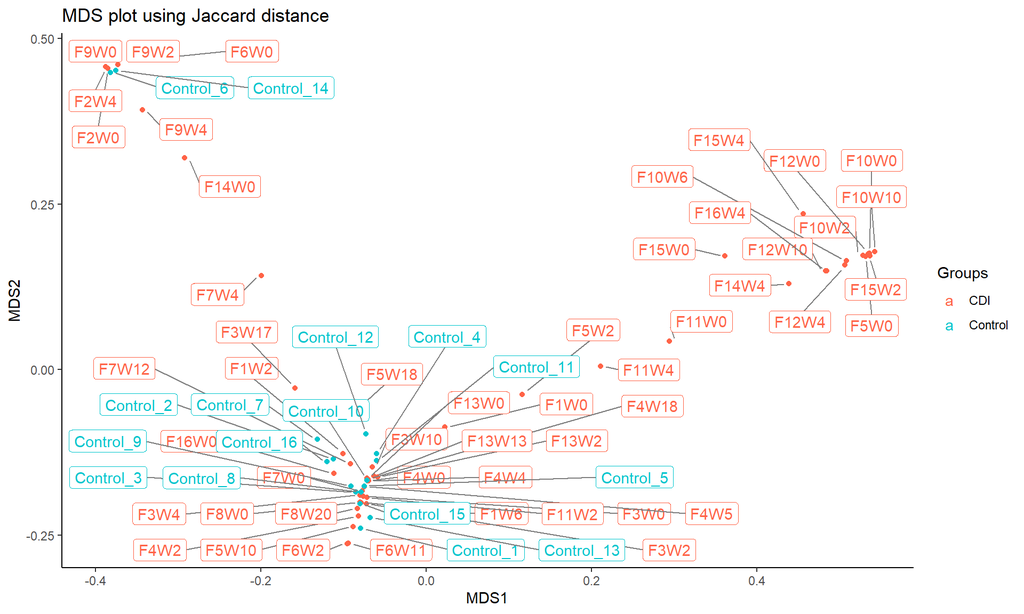

> **Figure 6.** MDS plot using Jaccard distance (vegan::vegdist & stats::cmdscale).

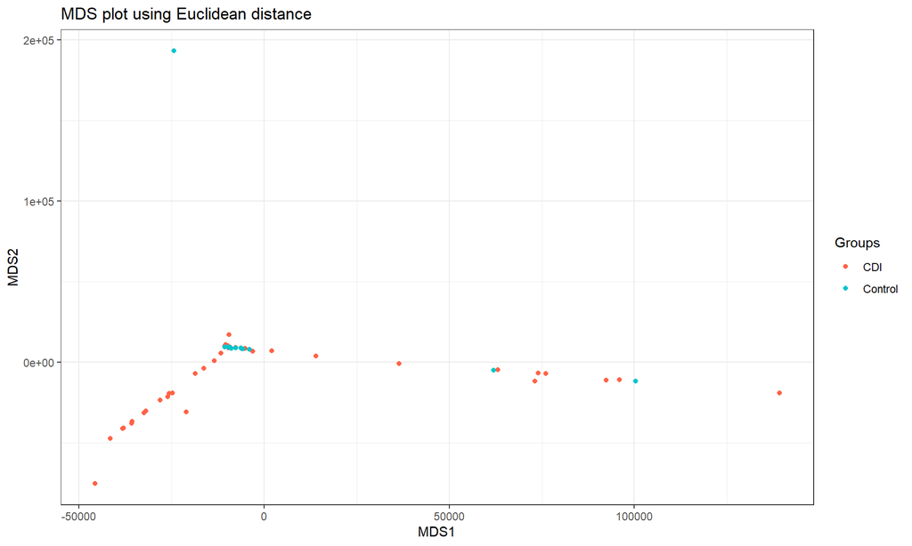

> **Figure 7.** MDS plot using Euclidean distance (vegan::vegdist & stats::cmdscale).

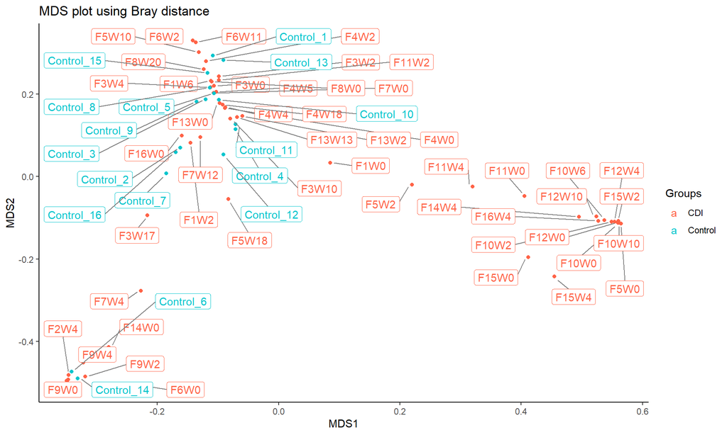

> **Figure 8.** MDS plot using Bray–Curtis distance (vegan::vegdist & stats::cmdscale).

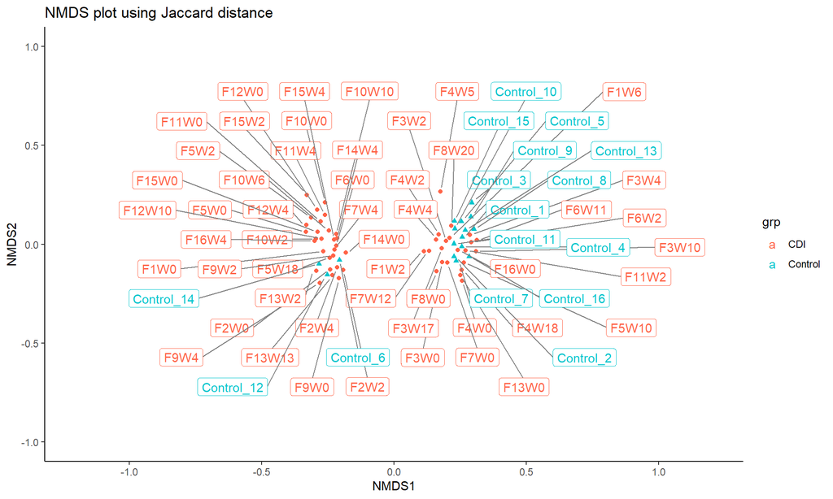

> **Figure 9.** NMDS plot using Jaccard distance (vegan::metaMDS).

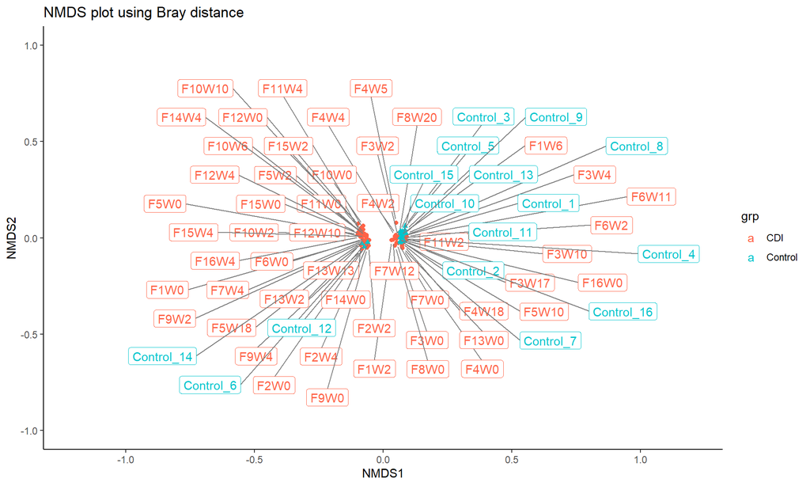

> **Figure 10.** NMDS plot using Bray–Curtis distance (vegan::metaMDS).

**References**<sup>Return</sup>

[1] Hildebrand, F., Tadeo, R., Voigt, A., Bork, P., & Raes, J. (2014). LotuS: an efficient and user-friendly OTU processing pipeline. Microbiome, 2(1), 30. https://doi.org/10.1186/2049-2618-2-30

[2] Lever, J., Krzywinski, M., & Altman, N. (2017). Principal component analysis. Nature Methods, 14(7), 641–642. https://doi.org/10.1038/nmeth.4346

[3] McCarthy, B. (n.d.). Ordination & PCA. [pdf] Available at: https://www.ohio.edu/plantbio/staff/mccarthy/multivariate/Ordination&PCA2012.pdf [Accessed 3 Dec. 2019].

[4] McCarthy, B. (n.d.). PCO and NMDS. [pdf] Available at: https://www.ohio.edu/plantbio/staff/mccarthy/multivariate/PCO&NMDS.pdf [Accessed 3 Dec. 2019].

[5] (MS) Multidimensional Scaling. (n.d.). [pdf] NCSS. Available at: https://ncss-wpengine.netdna-ssl.com/wp-content/themes/ncss/pdf/Procedures/NCSS/Multidimensional_Scaling

[6] (OM) Ordination Methods - an Overview. (n.d.). Retrieved December 4, 2019, from http://ordination.okstate.edu/overview.htm

[7] Shlens, J. (2014). A Tutorial on Principal Component Analysis. [pdf] Mountain View, CA. Available at: https://arxiv.org/pdf/1404.1100.pdf [Accessed 3 Dec. 2019].

[8] (SV) Singular Value Decomposition (SVD) tutorial. (n.d.). Retrieved December 3, 2019, from https://web.mit.edu/be.400/www/SVD/Singular_Value_Decomposition.htm

[9] Smith, L. (2002). A tutorial on Principal Components Analysis. [pdf] Available at: http://www.iro.umontreal.ca/~pift6080/H09/documents/papers/pca_tutorial.pdf [Accessed 3 Dec. 2019].

[10] Wold, S., Esbensen, K., & Geladi, P. (1987). Principal component analysis. Chemometrics and Intelligent Laboratory Systems, 2(1–3), 37–52. https://doi.org/10.1016/0169-7439(87)80084-9

[11] Zuo, T., Wong, S. H., Cheung, C. P., Lam, K., Lui, R., Cheung, K., … Ng, S. C. (2018). Gut fungal dysbiosis correlates with reduced efficacy of fecal microbiota transplantation in Clostridium difficile infection. Nature Communications, 9(1), 3663. https://doi.org/10.1038/s41467-018-06103-6